# BSAN2204

Tutorial 4

Data Processing

R Skills Quiz Preparation

## Today’s tutorial

We will focus on the **Data Processing** steps you needed to get started on the **Predictive Analytics Report (A2)** using the `MSD.Rdata` file.

We will start with some simple **console commands** to convince ourselves we know our data.

Next we will edit the `.Rmd` file from last week to include code for reading in the data, processing and structuring the dataset to have labels on factor variables, drawing an initial subset, and splitting the subset into data for model training and testing.

## Discussion questions

Lets first check that we are all on the same page. Around your table, check that the person next to you can demonstrate their ability to do the following (be kind and offer them help if necessary!):

1. Can your neighbour load the `MSD.RData` file using the `load()` function without specifying a file path? (this is important to avoid file loading errors when knitting on different systems).
2. Is your neighbouring including the `load()` function inside the source pane in R Studio (i.e., within an R chunk in their `.Rmd` file, and not just clicking on the file from the Files panel).
3. Is your neighbour saving their `.Rmd` file to a *sensible* location on their computer? (e.g., …username/documents/BSAN2204/)

## The Million Song Dataset (MSD)

The Million Song Dataset (`MSD`) contains metadata about 1 million songs, including their musical features, titles, year of release as well as “hotness” scores for each song and artist, and “familiarity” scores for each artist.

The dataset is incomplete in some parts (i.e. values are missing for some observations). Further, the data is missing several variables from the original larger dataset it is drawn.

The MSD is a useful dataset for us to learn basic `R` for business analytics.

## Predictive Analytics Report (A2)

The **Predictive Analytics Report (A2)** has 4 main sections.

Today, we will focus on the **Data Processing** steps which should be included within the **Introduction** section.

Exploring, describing and visualising the contents of the `MSD` is the focus of the **Exploratory Analysis** section of the report, whilst building training models with regression, dealing with missing data and testing models by conducting model validation is the focus of the **Predictive Analytics** section. The final **Recommendations** section summarises what you have learnt from the data and outlines what you would recommend to do next.

## Purpose of the report

The purpose of the **Predictive Analytics Report (A2)** is to provide a context for you to explore using `R`, applying statistical methods of business analytics, and to report the results with an R Markdown document.

There is no specific business problem to answer or contextualisation expected for the **Predictive Analytics Report (A2)**. Further, it is not expected that you necessarily locate models with strong fit to the data.

It is expected that you objectively report your findings from the data and make recommendations which are inline with those findings, use `R` correctly, and use R Markdown effectively to produce an accessible, easy to read, well formatted document.

## Data Processing the `MSD`

In the last session we built a template `.Rmd` file complete with all the section and subsection headings needed for the **Predictive Analytics Report (A2)**. If you have not done this, you will need to revise the previous tutorial notes.

You may have already included the first line of code required within the **Introduction** section inside a named R chunk. Recall the keyboard short cut to insert an R chunk is `ctrl alt i` (Windows) or `Cmd Option I` (Mac).

````markdown
## 1. Introduction

### Data Processing

```{r data processing}
load('MSD.RData')
```

...
````

## Running code blocks

It is recommended to run your code as your write it to ensure it works (rather than scouring your document during knitting!). When code is run this way, objects will be saved to the **global environment** and will be visible within the Environment tab in R studio.

To run a single line code from within your `.Rmd` file, place your cursor anywhere on the line you wish to run and press `ctrl ENTER` (Windows) or `cmd RETURN` (Mac).

To run a whole fenced off code block, press the green arrow that sits to the side of the code block.

## Loading the `MSD.Rdata` file

The first piece of `R` code required in your `.Rmd` file is the code to load data. When we are **knitting** the report into a `.html` the `MSD` data frame needs to be included at the start of the `.Rmd` file so that it is available in the **local environment**.

```r
load('MSD.RData')
```

When the `MSD.RData` is in the root directory of your working directory, you do not need to include the absolute path to the file inside the `load()` function. This is best practice to ensure your file is portable (sharable with others).

## Error

`[...]` `'No such file or directory'`

If you get this error message it means you do not have the `MSD.RData` in the same location as your `.Rmd` file. To fix this, ensure you have created a BSAN2204 folder somewhere on your computer, have saved the `MSD.RData` file to that folder, and have also saved your current `.Rmd` file to that folder.

It is also useful to set the working directory to the location of your `.Rmd` (so you can easily see what files are in this folder from the Files pane in RStudio).

[figure not shown]

## Global environment

Before knitting the `.Rmd`, we will work with the `MSD` from the **global environment**, using console commands to inspect its contents before we start writing our data processing code.

When you load `MSD.Rdata` into the global environment, it will appear in the Environment tab like this:

[figure not shown]

We can now start exploring the data in the `MSD`.

## Inspecting the `MSD`

We will begin by inspecting the `MSD` using simple console commands. We will **NOT** include these commands in the `.Rmd` file, because these commands will all generate raw console text outputs which we do not want to be outputted in the rendered `.html` file.

The purpose of inspecting the data this way first is to simply inform ourselves what we are working with before moving onto our data processing steps.

## Viewing the entire dataset

Click the icon from within the Environmental panel in R Studio.

This will send and execute the `View(MSD)` command from console and open `MSD` in a spreadsheet-style viewer (you could also type `View(MSD)` in the console and achieve the same thing).

Viewing the `MSD` this way allows us to scroll, sort, filter, the data, as well as look at the column headers, row numbers, and variable types, all without printing anything to the console. Although, just as would the case if were using Excel spreadsheet, interacting with the full `MSD` (all 1,000,000 songs) this way will be slow (or might crash your computer!).

## Inspecting the head rows

Viewing a small snippet of data, rather than the entire dataset, is a more efficient way to get a quick idea of what the dataframe contains. It is not necessary to see all 1,000,000 rows! The `head()` function will output the few rows and *all variables* of the data frame to the console. The output spills (wraps) over the horizontal width of the console pane. To see fewer columns of the data frame, try outputting some specific variables of interest using the methods of selecting specific objects (columns) discussed previously, for example:

```r
head(MSD)
```

```r
head(MSD$artist_name)
```

Run these lines in your **console window** (Do not include this in your `.Rmd` file!)

## Checking the data structure

Some further checks we can do in the console are to confirm that the `MSD` is *indeed* of the class `dataframe` and check how many rows and columns it holds.

```r
class(MSD)
str(MSD)
```

Check the number of number of rows, columns and names of all the columns using:

```r
nrow(MSD)
ncol(MSD)
names(MSD)
```

## Missing data in the `MSD`

Not all observations have values in every column of the `MSD`. We can assess the extent of this by summing across outputs which return `logical` values. In `R`, the `logical` value of `TRUE` is encoded with a value of `1` whilst `FALSE` is encoded with `0`. The command `is.na()` returns a vector of 1s and 0s, so applying `sum()` over this output will give us a count of missing data (`NA` values).

To count the extent of missing data in the whole data frame, use:

```r
sum(is.na(MSD))
```

To count the extent of missing data for a specific variable, use:

```r
sum(is.na(MSD$song_hotttnesss))
```

## What have we learnt about the MSD?

By now we should have a good idea about what kind of data we are working with. Some of this information can be summarised within the **Introduction** section of the **Predictive Analytics Report (A2)**.

To include these key facts about the data frame in the report, you should collate specific curated sections of the `MSD` together (i.e., selected columns) into a data frame and pipe it to the tabulation package `kable()` introduced in previous sessions. For individual values (number of rows, columns, extent of missing data, etc.), consider reporting these values using inline code, for example:

```markdown
There are `r nrow(MSD)` rows in the data. The value printed here is extracted from the data using inline code.
```

## Data Processing Subsection in `.Rmd`

At this point the *Data Processing* section should **only** contain the `load()` function to load the `MSD.Rdata` file. It should not include any code that would output console text to the `.html` file.

This is what the substantive parts of report should look like at this stage:

````markdown
## 1. Introduction

Text to introduce your report.

### Data Processing

Text explaining what the MSD is.

```{r data processing}
load('MSD.RData')
```
````

See the previous tutorial if you have not setup a blank `.Rmd` yet.

## Data Processing steps

This is the sequence of steps you should take in the *Data Processing* section of your report.

1. Load data
2. Apply labels to factor variables
3. Draw an initial subset of the full data
4. Split the subset into data into training data and test data
5. Attach the training data

## Labelling factors

Factor variables in `R` are used to represent categorical data (variables that take on a limited number of distinct values or levels). In the `MSD` these are the variables `key`, `mode` and `time signature`. Labelling ensures outputs related to analysis of these variables is interpretable.

The following plot uses unlabelled data… does it make sense?

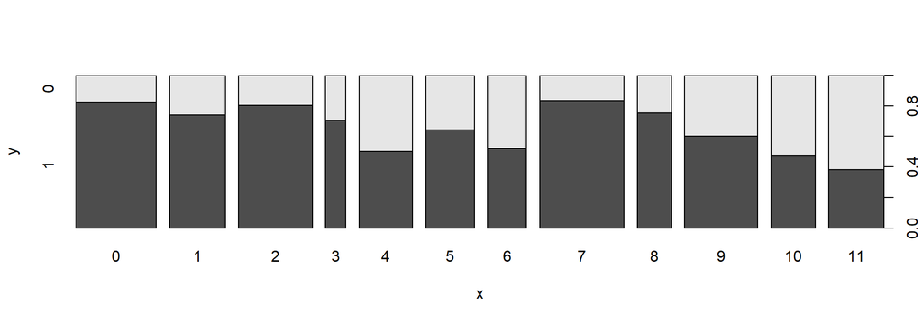

```r
plot(MSD$key, MSD$mode)
```

## Contextual knowledge

Proper labelling requires contextual knowledge about the data. Use human readable level names that align with the domain and your audience. For ordinal factors, set an explicit, meaningful order and reference level (e.g., None < Some < A lot), as this affects summaries, plots, and model contrasts. Keep labels consistent in spelling and capitalisation across datasets so tables and figures read clearly.

For the MSD data, we need to know:

What is musical key?

What is musical mode?

What is time signature?

## Music lesson: `key`

Musical key defines the tonal centre of a piece of music. It is the pitch around which all other notes are organised. When combined with a mode (major or minor), it determines the *scale* that governs the harmonic and melodic structure of the music. In Western music, there are 12 distinct keys in the chromatic scale. Each key can be expressed in major or minor mode, giving a total of 24 key-mode combinations.

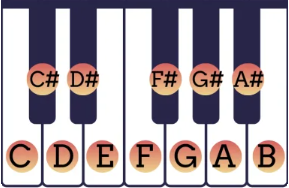

Click here to read more about key

## Music lesson: `mode`

The mode of a song determines the overall “tonality” of music (in the `MSD` it is essentially the “average key” which estimated algorithmically from analysis of the digital audio file). Major keys sound happy, while minor keys sound sad.

Pop music is tends to be in the major key. If we quickly output a frequency table of `mode` to the console, whichever of the two current labels “0” and “1” is more common can pretty reliably be assumed to be “major” whilst the less common mode will likely be “minor”.

```r
table(MSD$mode)
```

```
     0      1
333592 666408
```

[Click here to listen to a comparison major and minor scales](https://www.youtube.com/watch?v=_dVFknALySA)

## Music lesson: `time_signature`

Time signature tells you the rhythm of a song. Time signatures are written as two numbers stacked vertically (like a fraction). In the `MSD` the time signatures are estimated by using an algorithm to count the number of beats per 4 beat bar, and are categorised into 5 levels.

Pop music is very commonly in 4/4, especially club music. ONE-two-three-four, ONE-two-three-four…

The opening part of the Harry Potter main theme (“Hedwig’s Theme”) is in 3/4. Count: ONE-two-three, ONE-two-three…

Other time signatures are comparatively a lot rarer, often associated with esoteric music, although not always!

[Click here to listen to some songs 7/4 (Septuple)](https://www.youtube.com/watch?v=C9IBxtMxTLI)

## Using `factor()`

```r
MSD$key <- factor(MSD$key, levels = 0:11, labels =
              c("C", "C#/Db", "D", "D#/Eb", "E", "F", "F#/Gb", "G", "G#/Ab", "A", "A#/Bb", "B"))

MSD$mode <- factor(MSD$mode, levels = c(0, 1), labels = c("minor", "major"))

MSD$time_signature <- factor(MSD$time_signature,
                      levels = c(1, 3, 4, 5, 7),
                      labels = c("Unknown",
                                 "3/4 (Triple)",
                                 "4/4 (Common)",
                                 "5/4 (Quintuple)",
                                 "7/4 (Septuple)"))
```

`factor()` replaces the existing level codes with the labels listed in `labels =`

Here we have applied the labelling to the full `MSD` data. This is important to ensure the labels carry through to the subsets we will draw next.

## Check `plot(key,mode)`

### Now with added labels

The labels should now appear on the plot axes and within tables, making them minimally interpretable.

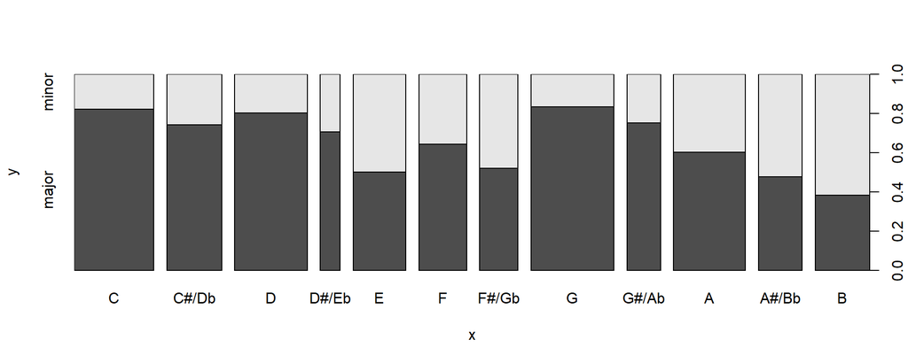

```r
plot(MSD$key, MSD$mode)
```

## Next subsection: Subsetting

````markdown
## 1. Introduction

### Data Processing

Words.

```{r data processing}
load('MSD.RData')
```

### Labelling

Words.

```{r labelling}
the code from above
```

### Subsetting

Words.

```{r subsetting}
the code we are about to write
```
````

## Subsetting

Subsetting in `R` refers to the process of extracting specific elements from an object. The `MSD` object is a data frame which has multiple rows and columns, hence we can use square brackets `[]` to select which of those rows and columns to subset.

First: We will draw an initial subset from the full `MSD`.

Second: We will split this subset into data to use for model training and data to use for model evaluation/testing (which we will refer to as the “training data” and the “test data”).

The training set will be used for all our analysis, including exploratory data analysis and regression models, whilst test data will be set aside returned to when we conduct model validation at the end of the report.

## Subsetting methods

### (Option 1: Random sampling)

Random sampling allows us to assume that the subset selected remains statistically representative of the larger population from which it is drawn. When a random sample is drawn it is important use **set.seed()** to ensure the result it reproducible. You can use any number as the seed value.

```r
set.seed(241281234)
MSD_subset <- MSD[sample(1:nrow(MSD), size = 12500), ]
```

Code logic: In the row reference section of `MSD[row,column]` we have the function `sample()` to randomly sample 12,500 observations from row 1 through to the row number returned by `nrow(MSD)` (i.e., rows 1 to 1,000,000).

## Subsetting methods

### (Option 2: Targeted sample)

If you want to tailor your project to specific business problem to answer or contextualisation (optional, not expected) you might consider drawing the initial subset based on the range of specific variables. For example, if you are only interested in songs released during a particular era (e.g., the 80s):

```r
MSD_subset_1980s <- MSD[!is.na(MSD$year) & MSD$year > 1980 & MSD$year < 1990, ]
```

This method would result in a subset of songs that have no missing data on `year`, and have values of `year` which are between 1980 and 1990. The resulting subset might still be quite large. In this case, you might need to then randomly sample again from within that subset to reduce its size to something more manageable.

## Which initial subset option to use?

Either the random sampling or targeted sampling method is appropriate for the initial subset. In either case, you should provide a **justification** in your report with the reason(s) for your choice in the narrative text that will surround your code.

Make sure you **keep all the variables** in your subset. Include all columns by leaving the second element within the `[]` part of your subsetting code **blank**.

Your *initial* subset size should be about 10,000 ~ 30,000 rows. There is no exact number of observations you must work with so feel free to experiment with larger subsets (but do not push your laptop too far, else you will not be able to render your report file!).

## Splitting `MSD_subset`

The next step is to split the initial subset into data to use for *training** and data for *testing**. Call the split datasets `training_data` and `test_data`.

```r
training_index <- sample(1:nrow(MSD_subset), size = 0.80 * nrow(MSD_subset))

training_data <- MSD_subset[training_index, ]
test_data     <- MSD_subset[-training_index, ]
```

If the initial subset `MSD_subset` contains 12,500 rows, then using a 80%/20% split per above will result in `training_data` containing 10,000 rows and `test_data` containing 2,500 rows. Use console commands to check that your subset has the number of rows you expect.

In the code above, I am splitting `MSD_subset` (not `MSD_subset_1980s`).

## Checking the `training_data` structure

Before proceeding to the next step, run some quick checks in the console on the `training_data` data frame. Satisfy yourself that it has the structure you expect:

1. How many rows are in your `training_data`?
2. How many columns are in your `training_data`?
3. What are the names of the variables in your `training_data`?

After you have convinced yourself you have properly set up your `training_data`, report some key facts about it in your report using the same methods used to describe the full `MSD`.

## Using `attach()`

When we were exploring the `MSD` in the console window, we had to use `[]` or `$` to access variables within it. By attaching the `training_data` data frame we will be able to access the variables in it without needing to explicitly name the data frame every time.

Once you have created the `training_data` object, make its columns available directly by using `attach()`.

```r
attach(training_data)
```

## Check `attach()` has worked

Run some basic console commands without naming the data frame to check you have the correct data attached. I am going to use `length()` on a variable name that should have complete information (`artist_name`).

If the result is `10,000` (instead of `1,000,000` or `2,500`) then I will know I have the correct data frame attached.

```r
length(artist_name)
```

```
[1] 10000
```

## Exploratory Analysis

Once you have **convinced yourself** that you have properly drawn an initial subset, split it into training and test data and have attached `training_data` then you are ready to move on to next main section of the report: **Exploratory Analysis**.

This section of the report will document your exploration of the now fully processed `training_data` object we have just attached. This section will comprise using descriptive statistics and data visualisations.

If you have not already, you can prepare for this by ensuring you have the main section and subsection headings in your `.Rmd` file.

## Next session: R Skills Quiz (A1)

The quiz will consist of 30 multiple‑choice questions assessing your understanding of core `R` concepts, including basic functions, syntax, RStudio, and RMarkdown. Some questions will be conceptual (about `R`) whilst others will be practical code questions (e.g., choosing the correct syntax).

The quiz is paper‑based. You may not bring notes, devices, or any electronic aids.

You must sit the quiz in your allocated tutorial unless you have received permission from the Course Coordinator to attend a different session.

## Example Questions on R Skills Quiz (A1)

Which of the following is accurately describes the difference in purpose of the R script editor window vs the R console window within R studio.

a) The R script editor is where R scripts are executed, whilst the console window is where R scripts are written and edited.

b) The R script editor is an interactive environment for modifying R packages, whilst the R console is where R packages are stored.

c) The R script editor is used to adjust R studio settings, whilst the R console is where R plots/graphics are displayed.

d) The R script editor is where R scripts are written and edited, whilst the console is where R scripts are executed and text outputs are displayed.

Which of these is correct?

## Example Questions on R Skills Quiz (A1)

Which line of R code which creates object called “my_vector” that contains a numeric vector of numbers from 1 to 10?

a) `my_vector <- c(1:10)`

b) `my vector <- c(1:10)`

c) `my_vector <- 1,2,3,4,5,6,7,8,9,10`

d) `my_vector <- combine(1 to 10)`

Which of these is correct?

a) is correct

b) is wrong, as variable names cannot contain spaces,

c) is wrong, as `1,2,3...` is not valid syntax,

d) is wrong, as `combine(1 to 10)` is not valid syntax.

## Preparing for the R Skills Quiz (A1)

The quiz assesses core skills and concepts covered in tutorials and lectures. Revise the slides-many correct answers (both text and code) appear verbatim there.

Doing well requires a solid grasp of the basics from the first part of the course, and these same skills are the foundation you will need to start the **Predictive Analytics Report (A2)**.

Tip: Focus on syntax, key functions, RStudio workflow, and R Markdown conventions that are emphasised in the slides.

Thank you!